# practical machine learning project

Itay Carmel

February 27, 2020

## The goal

The mission in this project is to train a model on dataset of people exercise to predict the manner in which they did the exercise.which is “classe” variable.

## Building the model

First, we downloaded and read the file:

```r
url<-"https://d396qusza40orc.cloudfront.net/predmachlearn/pml-training.csv"
destfile<-"C:/Users/ICarmel/Documents/R/pmltraining.csv"
download.file(url,destfile)
mydata<-read.csv("pmltraining.csv")
```

Next, we explore the data:

```r
dim(mydata)
```

```
## [1] 19622   160
```

```r
names(mydata)
```

```
##   [1] "X"                        "user_name"
##   [3] "raw_timestamp_part_1"     "raw_timestamp_part_2"
##   [5] "cvtd_timestamp"           "new_window"
##   [7] "num_window"               "roll_belt"
##   [9] "pitch_belt"               "yaw_belt"
##  [11] "total_accel_belt"         "kurtosis_roll_belt"
##  [13] "kurtosis_picth_belt"      "kurtosis_yaw_belt"
##  [15] "skewness_roll_belt"       "skewness_roll_belt.1"
##  [17] "skewness_yaw_belt"        "max_roll_belt"
##  [19] "max_picth_belt"           "max_yaw_belt"
##  [21] "min_roll_belt"            "min_pitch_belt"
##  [23] "min_yaw_belt"             "amplitude_roll_belt"
##  [25] "amplitude_pitch_belt"     "amplitude_yaw_belt"
##  [27] "var_total_accel_belt"     "avg_roll_belt"
##  [29] "stddev_roll_belt"         "var_roll_belt"
```

[output cut: 65 more lines]

```r
str(mydata)
```

```
## 'data.frame':    19622 obs. of  160 variables:
##  $ X                       : int  1 2 3 4 5 6 7 8 9 10 ...
##  $ user_name               : Factor w/ 6 levels "adelmo","carlitos",..: 2 2 2 2 2 2 2 2 2 2 ...
##  $ raw_timestamp_part_1    : int  1323084231 1323084231 1323084231 1323084232 1323084232 1323084232 1323084232 1323084232 1323084232 1323084232 ...
##  $ raw_timestamp_part_2    : int  788290 808298 820366 120339 196328 304277 368296 440390 484323 484434 ...
##  $ cvtd_timestamp          : Factor w/ 20 levels "02/12/2011 13:32",..: 9 9 9 9 9 9 9 9 9 9 ...
##  $ new_window              : Factor w/ 2 levels "no","yes": 1 1 1 1 1 1 1 1 1 1 ...
##  $ num_window              : int  11 11 11 12 12 12 12 12 12 12 ...
##  $ roll_belt               : num  1.41 1.41 1.42 1.48 1.48 1.45 1.42 1.42 1.43 1.45 ...
##  $ pitch_belt              : num  8.07 8.07 8.07 8.05 8.07 8.06 8.09 8.13 8.16 8.17 ...
##  $ yaw_belt                : num  -94.4 -94.4 -94.4 -94.4 -94.4 -94.4 -94.4 -94.4 -94.4 -94.4 ...
##  $ total_accel_belt        : int  3 3 3 3 3 3 3 3 3 3 ...
##  $ kurtosis_roll_belt      : Factor w/ 397 levels "","-0.016850",..: 1 1 1 1 1 1 1 1 1 1 ...
##  $ kurtosis_picth_belt     : Factor w/ 317 levels "","-0.021887",..: 1 1 1 1 1 1 1 1 1 1 ...
##  $ kurtosis_yaw_belt       : Factor w/ 2 levels "","#DIV/0!": 1 1 1 1 1 1 1 1 1 1 ...
```

[output cut: 86 more lines]

About 67 variables are actually missing, noted as NA, i.e are meaningless for our pourpose.

Therefore it would make sense to omit them from the dataset:

```r
mydata<-mydata[ , apply(mydata, 2, function(x) !any(is.na(x)))]
```

We are left with 93 variable and 19622 observations(rows).

We will Split the data based on the “classe” variable so we could train the model on the training portion and than test it on new data.

```r
inTrain <- createDataPartition(mydata$classe, p = 3/4)[[1]]
training <- mydata[ inTrain,]
testing <- mydata[-inTrain,]
```

Now we should estimate the importance of each variable and its potential contribution to our model.

To do this, we will use Boruta package. Boruta is a feature ranking and selection algorithm based on random forests algorithm.

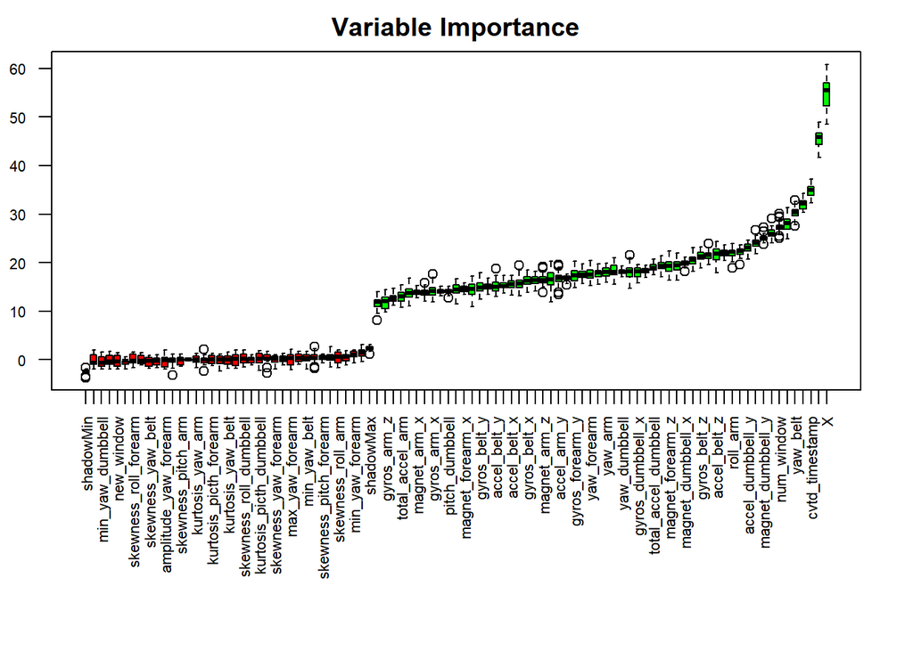

```r
par(mar = c(10, 2, 2,2))
plot(boruta_output, cex.axis=.7, las=2, xlab="", main="Variable Importance")
```

```r
roughFixMod <- TentativeRoughFix(boruta_output)
imps <- attStats(roughFixMod)
imps2 = imps[imps$decision != 'Rejected', c('meanImp', 'decision')]
head(imps2[order(-imps2$meanImp), ],6)
```

```
##                       meanImp  decision
## X                    54.93618 Confirmed
## raw_timestamp_part_1 45.72889 Confirmed
## cvtd_timestamp       34.90563 Confirmed
## roll_belt            32.04918 Confirmed
## yaw_belt             30.30517 Confirmed
## pitch_belt           28.07317 Confirmed
```

The graph as well as the list we got tells us the importance rate of the variables.

However, since “cvtd_timestamp” is actually the date and time the activity was measured we will exclude it from the variables list.

Now we will train a random forest model. We based on random forest algorithm for two reason:

1. It provides higher accuracy.
2. It has the power to handle a large data set with higher dimensionality.

In addintion, in random forests, there is no need for cross-validation or a separate test set to get an unbiased estimate of the test set error. It is estimated internally, during the run, as follows:

Each tree is constructed using a different bootstrap sample from the original data. About one-third of the cases are left out of the bootstrap sample and not used in the construction of the kth tree ( a snippet from [Breiman’s official documentation](https://www.stat.berkeley.edu/~breiman/RandomForests/cc_home.htm#ooberr))

```r
library(randomForest)
model<-randomForest(classe~raw_timestamp_part_1+roll_belt+yaw_belt+pitch_belt+num_window,data=training)
print(model)
```

```
##
## Call:
##  randomForest(formula = classe ~ raw_timestamp_part_1 + roll_belt +      yaw_belt + pitch_belt + num_window, data = training)
##                Type of random forest: classification
##                      Number of trees: 500
## No. of variables tried at each split: 2
##
##         OOB estimate of  error rate: 0.04%
## Confusion matrix:
##      A    B    C    D    E  class.error
## A 4185    0    0    0    0 0.0000000000
## B    1 2847    0    0    0 0.0003511236
## C    0    1 2565    1    0 0.0007791196
## D    0    0    0 2411    1 0.0004145937
## E    0    1    0    1 2704 0.0007390983
```

```r
pred<-predict(model,testing)
confusionMatrix(pred,testing$classe)
```

```
## Confusion Matrix and Statistics
##
##           Reference
## Prediction    A    B    C    D    E
##          A 1395    0    0    0    0
##          B    0  949    0    0    0
##          C    0    0  855    0    0
##          D    0    0    0  804    0
##          E    0    0    0    0  901
##
## Overall Statistics
##
##                Accuracy : 1
##                  95% CI : (0.9992, 1)
##     No Information Rate : 0.2845
##     P-Value [Acc > NIR] : < 2.2e-16
##
##                   Kappa : 1
##
##  Mcnemar's Test P-Value : NA
##
## Statistics by Class:
##
##                      Class: A Class: B Class: C Class: D Class: E
## Sensitivity            1.0000   1.0000   1.0000   1.0000   1.0000
## Specificity            1.0000   1.0000   1.0000   1.0000   1.0000
## Pos Pred Value         1.0000   1.0000   1.0000   1.0000   1.0000
## Neg Pred Value         1.0000   1.0000   1.0000   1.0000   1.0000
## Prevalence             0.2845   0.1935   0.1743   0.1639   0.1837
## Detection Rate         0.2845   0.1935   0.1743   0.1639   0.1837
## Detection Prevalence   0.2845   0.1935   0.1743   0.1639   0.1837
## Balanced Accuracy      1.0000   1.0000   1.0000   1.0000   1.0000
```

Now we will run the model on the test data:

```r
url<-"https://d396qusza40orc.cloudfront.net/predmachlearn/pml-testing.csv"
destfile<-"C:/Users/ICarmel/Documents/R/pmltest.csv"
download.file(url,destfile)
testdata<-read.csv("pmltest.csv")
predtest<-predict(model,testdata)
print(predtest)
```

```
##  1  2  3  4  5  6  7  8  9 10 11 12 13 14 15 16 17 18 19 20
##  B  A  B  A  A  E  D  B  A  A  B  C  B  A  E  E  A  B  B  B
## Levels: A B C D E
```